# Lab 1 - Bivariate Analysis

Raven W.

### Installation and Setup

```r
# Install Packages
# install.packages("package") - syntax to install packages in R
# install.packages("tidyverse")
# install.packages("devtools")
# install.packages("remotes")
# install.packages("tigris")
#install.packages("descr")

# Load the necessary libraries needed for today's analyses
library(tidyverse) #collection of R packages designed for data science
library(dplyr)
library(remotes)
library(critstats)
library(glue)
library(ggplot2)
library(tigris)
library(descr)


## Update packages if needed; remove # to run code
# update.packages("critstats") # - syntax to update packages in R
```

## Part 1 - Extract Dataset from critstats

```r
data(package="critstats") # shows list of datasets in critstats package
??critstats::blackmedianincome
```

### Initial Dataset Exploration

```r
bmi <- critstats::blackmedianincome # assign dataset to main dataframe
# View(bmi)
```

## Part 2 - Dataset Cleaning/Modification and Analyis

```r
bmiC = critstats::blackmedianincome %>%
  na.omit() %>%
  select(NAME, estimate , moe, GEOID) %>%
  rename(income = estimate)%>%
  rename(state = NAME) %>%
  rename(geoid = GEOID)

bmiC # removed variable column, NA values, and rename 3 columns (estimate, NAME, and GEOID)
```

```
## # A tibble: 52 × 4
##    state                income   moe geoid
##    <chr>                 <dbl> <dbl> <chr>
##  1 Alabama               35239   496 01
##  2 Alaska                64054  4716 02
##  3 Arizona               49418  1488 04
##  4 Arkansas              32844   723 05
##  5 California            54976   602 06
##  6 Colorado              53806  1742 08
##  7 Connecticut           50905  1208 09
##  8 Delaware              50870  2077 10
##  9 District of Columbia  48515  1216 11
## 10 Florida               43418   442 12
## # ℹ 42 more rows
```

### Add Region Column to Dataset

- Added region column to help with capturing “state” like break/sentiments, for plotting sake. When plotting states (categorical) values against the black median income (numerical) values, the amount of states (52), it not as practical for every graph in this setting/environment. Further analysis, can be carried out at a bigger scale for some plots. By putting the states into regions made up of states, I was able to view states vs. income in a different way. I recognize that a deeper dive, could further enhance this analysis.

```r
# Add region column
# Define regions (consisting of states)
northeast <- c("Maine","New Hampshire","Vermont","Massachusetts","Rhode Island","Connecticut","New York","New Jersey","Pennsylvania")
midwest <- c("Ohio","Indiana","Illinois","Michigan","Wisconsin","Minnesota","Iowa","Missouri","North Dakota","South Dakota","Nebraska","Kansas")
south <- c("Delaware","Maryland","District of Columbia","Virginia","West Virginia","North Carolina","South Carolina","Georgia","Florida",
           "Kentucky","Tennessee","Mississippi","Alabama","Oklahoma","Texas","Arkansas","Louisiana")
west <- c("Montana","Idaho","Wyoming","Colorado","New Mexico","Arizona","Utah","Nevada","Washington","Oregon","California","Alaska","Hawaii")

# Add region column
bmiC<- bmiC %>%
  mutate(region = case_when(
    state %in% northeast ~ "Northeast",
    state %in% midwest ~ "Midwest",
    state %in% south ~ "South",
    state %in% west ~ "West",
    TRUE ~ "Other"
  ))
```

### Total States Unique Count

- **Assumption:** “States” refer to the 50 CONUS (Continental U.S.) states, Washington, D.C., and Puerto Rico.
- Counts the unique states in the states column
- Lists all the states.

```r
# Count unique states
# Assumptions - "states" refers to the 50 CONUS states, Washington, D.C., and Puerto Rico
total_states_count = length(unique(bmiC$state)) # counts unique states in states column
total_states_lst = (bmiC$state)

# Print all states (includes 50 states, PR, and D.C.)
print(total_states_lst)
```

```
##  [1] "Alabama"              "Alaska"               "Arizona"
##  [4] "Arkansas"             "California"           "Colorado"
##  [7] "Connecticut"          "Delaware"             "District of Columbia"
## [10] "Florida"              "Georgia"              "Hawaii"
## [13] "Idaho"                "Illinois"             "Indiana"
## [16] "Iowa"                 "Kansas"               "Kentucky"
## [19] "Louisiana"            "Maine"                "Maryland"
## [22] "Massachusetts"        "Michigan"             "Minnesota"
## [25] "Mississippi"          "Missouri"             "Montana"
## [28] "Nebraska"             "Nevada"               "New Hampshire"
## [31] "New Jersey"           "New Mexico"           "New York"
## [34] "North Carolina"       "North Dakota"         "Ohio"
## [37] "Oklahoma"             "Oregon"               "Pennsylvania"
## [40] "Rhode Island"         "South Carolina"       "South Dakota"
## [43] "Tennessee"            "Texas"                "Utah"
## [46] "Vermont"              "Virginia"             "Washington"
## [49] "West Virginia"        "Wisconsin"            "Wyoming"
## [52] "Puerto Rico"
```

```r
# Print column names
glue("Column Names: {colnames(bmiC)}")
```

```
## Column Names: state
## Column Names: income
## Column Names: moe
## Column Names: geoid
## Column Names: region
```

### Black Median Income By State vs. U.S. National Median Income

For the sake of this analysis, we will not include P.R. in the following chart due to lack of data/reputable sources for the median income in 2020.

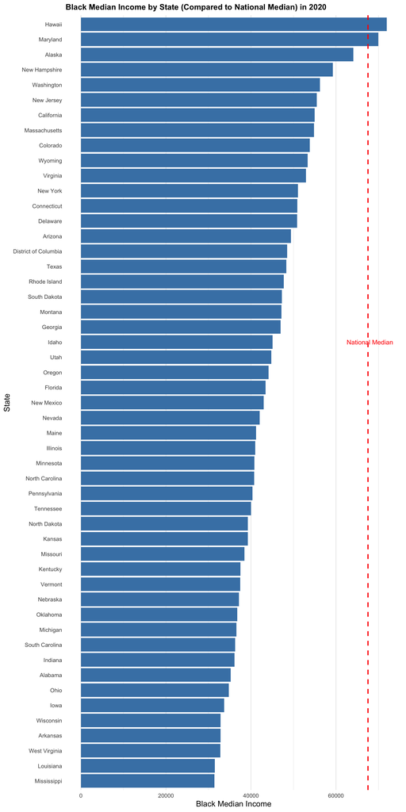

```r
med_USincome_2020 = 67521 # excludes PR, gathered from

library(ggplot2)

ggplot(head(bmi, n=51), aes(x = reorder(NAME, estimate), y = estimate)) +
  geom_col(fill = "steelblue") +
  geom_hline(yintercept = med_USincome_2020, color = "red", linetype = "dashed", size = 1) +
  coord_flip() +
  labs(
    x = "State",
    y = "Black Median Income",
    title = "Black Median Income by State (Compared to National Median) in 2020"
  ) +
  annotate(
    "text",
    x=30,
    y= med_USincome_2020 - 5000,
    label = paste("National Median"),
    color = "red", size = 4, hjust = 0
  ) +
  theme_minimal(base_size = 14) +  # bigger text
  theme(
    axis.text.y = element_text(size = 10),
    axis.text.x = element_text(size = 10),
    plot.title = element_text(face = "bold", size = 14),
    panel.grid.major.y = element_blank()  # removes distracting horizontal grid lines
  )
```

As can be seen above, the average Black median income in most states is well below the 2020 U.S. median income. To note, the median value shows the middle value in a dataset, meaning 50% of the data points are above it and 50% are below it, the median provides a measure of central tendency that is useful because it is not skewed by extremely high or low values, also known as outliers. It prompts a consideration, of the other demographic median incomes in comparison, and the effect of state citizenship, cost of living per state, and how that might impact the black median income. Therefore, to see that the Black median income in most states are well below the median income for the entire U.S., means that half of the Black population across the states may be making lower than the median values listed here, raising concern on Black well-being and livelihood, consider the varying deficits across all states.

### State with Highest Black Median Income

- Displays the state with the highest Black median income in 2020

```r
# Calculate highest black median income, denote the associated state
max_bmi_by_state = bmiC[bmiC$income == max(bmiC$income), c("state", "income")]
# print(max_bmi_by_state) # print subset df
max_state = toString(max_bmi_by_state[1])
max_state_income = as.integer(max_bmi_by_state[2])
glue("Emphasis: {max_state} has the highest black median income, ${max_state_income}")
```

```
## Emphasis: Hawaii has the highest black median income, $71939
```

### Top 10 States with Highest Black Median Income

- Displays the top 10 states with the highest Black median income in 2020

```r
# Show the top 10 states with the highest Black median income income
bmiC[head(order(-bmiC$income), n=10), c("state", "income", "region")]
```

```
## # A tibble: 10 × 3
##    state         income region
##    <chr>          <dbl> <chr>
##  1 Hawaii         71939 West
##  2 Maryland       69964 South
##  3 Alaska         64054 West
##  4 New Hampshire  59261 Northeast
##  5 Washington     56196 West
##  6 New Jersey     55453 Northeast
##  7 California     54976 West
##  8 Massachusetts  54835 Northeast
##  9 Colorado       53806 West
## 10 Wyoming        53354 West
```

### State with Lowest Black Median Income

- Displays the state with the lowest Black median income in 2020

```r
# Calculate lowest black median income, denote the associated state
min_bmi_by_state = bmiC[bmiC$income == min(bmiC$income), c("state", "income")]
# print(min_bmi_by_state) # print subset df
min_state = toString(min_bmi_by_state[1])
min_state_income = as.integer(min_bmi_by_state[2])

glue("Emphasis: {min_state} has the lowest black median income, ${min_state_income}.")
```

```
## Emphasis: Puerto Rico has the lowest black median income, $20038.
```

- For additional context, the size of Puerto Rico, is very small. It can be compared to Connecticut in size, and is just slightly smaller than the state. Connecticut is the third smallest state in the CONUS.
- Furthermore, the demographic makeup of Puerto Rico varies. While Black median income is deemed to be the lowest out of all 52 states, in 2020, 49.8% of people in PR are two or more races, while 7% listed they were Black or African-American alone. Keying into the history of Puerto Rico, it requires a deeper look into what is considered the “Black” community behind the critstats dataset value for PR Black Median Income. A combined look at Black alone, and Black+ populations, may present for a different median income value. [Link to Source](https://centropr.hunter.cuny.edu/app/uploads/2023/02/022223-Puerto-Ricos-2020-Race_Ethnicity-Decennial-Analysis.pdf)

### Top 10 states with Lowest Black Median Income

- Displays the top 10 states with the lowest Black median income in 2020

```r
# Show 10 states with the lowest Black median income income
# Show the top 10 states with the highest Black median income income
bmiC[head(order(bmiC$income), n=10), c("state", "income", "region")]
```

```
## # A tibble: 10 × 3
##    state         income region
##    <chr>          <dbl> <chr>
##  1 Puerto Rico    20038 Other
##  2 Mississippi    31389 South
##  3 Louisiana      31479 South
##  4 West Virginia  32803 South
##  5 Arkansas       32844 South
##  6 Wisconsin      32857 Midwest
##  7 Iowa           33662 Midwest
##  8 Ohio           34778 Midwest
##  9 Alabama        35239 South
## 10 Indiana        36131 Midwest
```

### Boxplot of Black Median Income (2020) by Region

- Boxplot of Black median income across regions (made up of states) shows the typical values, the spread, and any states with unusually high or low median income.

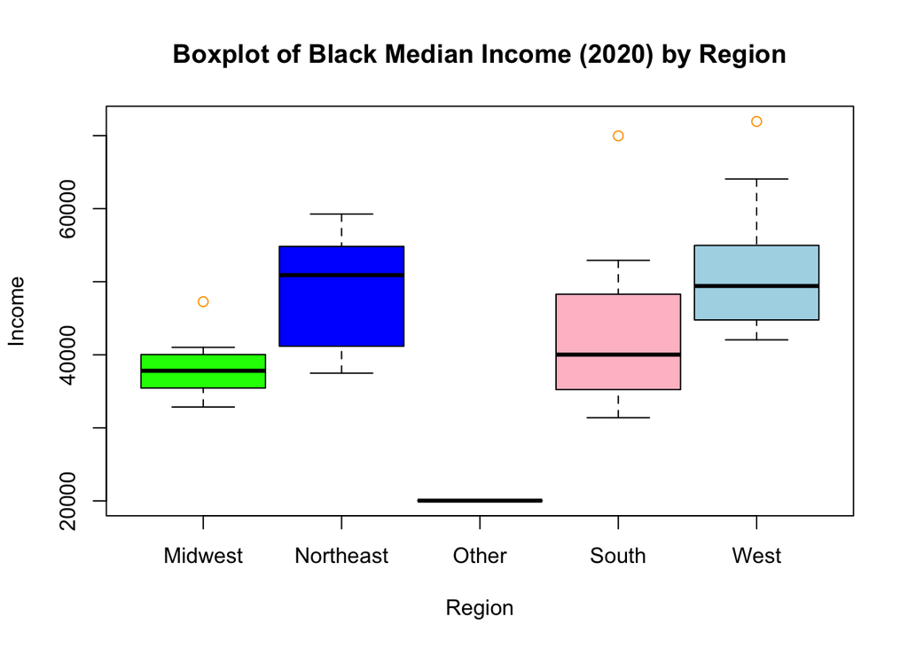

```r
boxplot(bmiC$income ~ bmiC$region,
        main="Boxplot of Black Median Income (2020) by Region",
        ylab="Income", xlab="Region",
        col = c("green", "blue", "orange", "pink", "lightblue"), outline=TRUE, outcol="orange", boxwex=0.9)
```

```r
# A boxplot shows how a numeric variable is spread out:
# - The middle line in the box is the median (middle value).
# - The box represents the middle 50% of the data (from the 25th to the 75th percentile).
# - The whiskers show the range of most of the data.
# - Any dots outside the whiskers are outliers (unusually high or low values).
```

### Analysis of Variance (ANOVA) Testing

- Furthering my bivariate analysis (categorical, numerical), I leveraged the ANOVA test for Black median income. The ANOVA test checks if the income differences seen from one state to the next are due to the states belonging to a specific region (like the South or the Northeast), or if those differences are just random and aren’t related to the region at all. After running the test on , I got a p-value of (0.000114). Sine this number is less than 0.05, the result is considered statistically significant (or reliable). Therefore, the region a state is in is a major, statistically confirmed factor that likely determines Black median income.The decision was made to select regions because there is likely too much variance between each individual state.

```r
print("Anova Result of Black Median Income, Region")
```

```
## [1] "Anova Result of Black Median Income, Region"
```

```r
anova_result <- aov(income ~ region, data = bmiC)
print(anova_result)
```

```
## Call:
##    aov(formula = income ~ region, data = bmiC)
##
## Terms:
##                     region  Residuals
## Sum of Squares  1983658307 3181828780
## Deg. of Freedom          4         47
##
## Residual standard error: 8227.909
## Estimated effects may be unbalanced
```

```r
print("Summary: Anova Result")
```

```
## [1] "Summary: Anova Result"
```

```r
print(summary(anova_result))
```

```
##             Df    Sum Sq   Mean Sq F value   Pr(>F)
## region       4 1.984e+09 495914577   7.325 0.000114 ***
## Residuals   47 3.182e+09  67698485
## ---
## Signif. codes:  0 '***' 0.001 '**' 0.01 '*' 0.05 '.' 0.1 ' ' 1
```

### States by Region

```r
# Southern States w/income df
south_bmi = bmiC[bmiC$region == "South", c("state", "income", "moe")]
print(south_bmi)
```

```
## # A tibble: 17 × 3
##    state                income   moe
##    <chr>                 <dbl> <dbl>
##  1 Alabama               35239   496
##  2 Arkansas              32844   723
##  3 Delaware              50870  2077
##  4 District of Columbia  48515  1216
##  5 Florida               43418   442
##  6 Georgia               46964   478
##  7 Kentucky              37521   821
##  8 Louisiana             31479   496
##  9 Maryland              69964   728
## 10 Mississippi           31389   507
## 11 North Carolina        40767   380
## 12 Oklahoma              36790  1019
## 13 South Carolina        36271   533
## 14 Tennessee             40020   640
## 15 Texas                 48293   463
## 16 Virginia              52929   688
## 17 West Virginia         32803  2764
```

```r
# Western States w/income df
west_bmi = bmiC[bmiC$region == "West", c("state", "income", "moe")]
print(west_bmi)
```

```
## # A tibble: 13 × 3
##    state      income   moe
##    <chr>       <dbl> <dbl>
##  1 Alaska      64054  4716
##  2 Arizona     49418  1488
##  3 California  54976   602
##  4 Colorado    53806  1742
##  5 Hawaii      71939  3276
##  6 Idaho       45059  4527
##  7 Montana     47177  8487
##  8 Nevada      42047  1092
##  9 New Mexico  42963  3691
## 10 Oregon      44138  2949
## 11 Utah        44772  5091
## 12 Washington  56196  2059
## 13 Wyoming     53354 21200
```

```r
# Midwestern States w/income df
mw_bmi = bmiC[bmiC$region == "Midwest", c("state", "income", "moe")]
print(mw_bmi)
```

```
## # A tibble: 12 × 3
##    state        income   moe
##    <chr>         <dbl> <dbl>
##  1 Illinois      41021   505
##  2 Indiana       36131   617
##  3 Iowa          33662  1625
##  4 Kansas        39274  1276
##  5 Michigan      36561   418
##  6 Minnesota     40785   960
##  7 Missouri      38456   836
##  8 Nebraska      37163  2527
##  9 North Dakota  39280  3971
## 10 Ohio          34778   441
## 11 South Dakota  47270  6998
## 12 Wisconsin     32857  1304
```

```r
# Northern States w/income df
north_bmi = bmiC[bmiC$region == "Northeast", c("state", "income", "moe")]
print(north_bmi)
```

```
## # A tibble: 9 × 3
##   state         income   moe
##   <chr>          <dbl> <dbl>
## 1 Connecticut    50905  1208
## 2 Maine          41174  4125
## 3 Massachusetts  54835  1789
## 4 New Hampshire  59261  6847
## 5 New Jersey     55453   912
## 6 New York       51060   508
## 7 Pennsylvania   40370   668
## 8 Rhode Island   47723  2986
## 9 Vermont        37489  9658
```

```r
# Other States w/income df
other_bmi = bmiC[bmiC$region == "Other", c("state", "income", "moe")]
print(other_bmi)
```

```
## # A tibble: 1 × 3
##   state       income   moe
##   <chr>        <dbl> <dbl>
## 1 Puerto Rico  20038   558
```

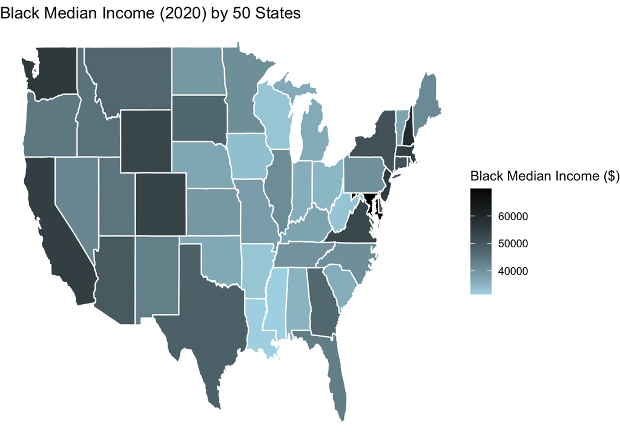

```r
library(maps)
library(dplyr)

us_states <- map_data("state")
bmiC <- bmiC %>% mutate(state = tolower(state))

plot_data <- us_states %>%
  left_join(bmiC, by = c("region" = "state"))

ggplot(plot_data, aes(long, lat, group = group, fill = income)) +
  geom_polygon(color = "white") +
  scale_fill_gradient(low = "lightblue", high = "black") +
  labs(fill = "Black Median Income ($)", title = "Black Median Income (2020) by 50 States") +
  theme_void()
```

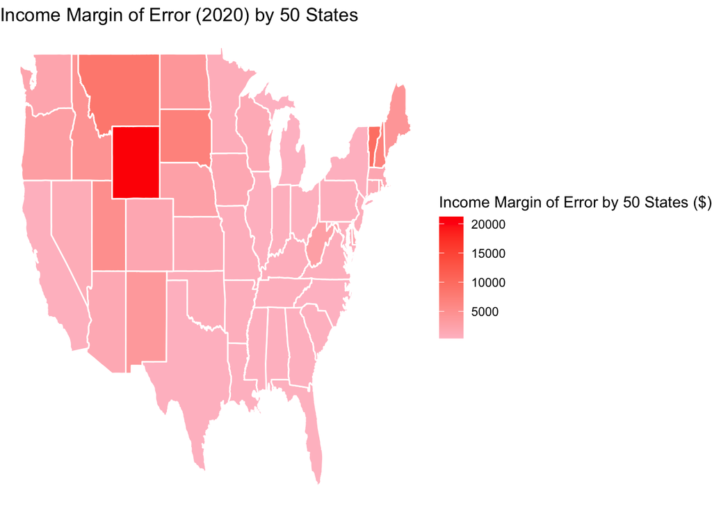

```r
library(maps)
library(dplyr)

us_states <- map_data("state")
bmiC <- bmiC %>% mutate(state = tolower(state))

plot_data <- us_states %>%
  left_join(bmiC, by = c("region" = "state"))

ggplot(plot_data, aes(long, lat, group = group, fill = moe)) +
  geom_polygon(color = "white") +
  scale_fill_gradient(low = "pink", high = "red") +
  labs(fill = "Income Margin of Error by 50 States ($)", title = "Income Margin of Error (2020) by 50 States") +
  theme_void()
```

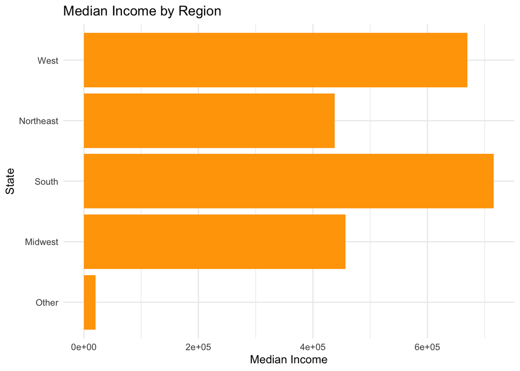

```r
library(ggplot2)

ggplot(bmiC, aes(x = reorder(region, income), y = income)) +
  geom_col(fill = "orange") +
  coord_flip() +
  labs(x = "State", y = "Median Income", title = "Median Income by Region") +
  theme_minimal()
```

```r
multi_model <- lm(income ~ region, data = bmiC)
summary(multi_model)
```

```
##
## Call:
## lm(formula = income ~ region, data = bmiC)
##
## Residuals:
##      Min       1Q   Median       3Q      Max
## -11207.7  -6006.3   -956.9   3750.3  27841.9
##
## Coefficients:
##                 Estimate Std. Error t value Pr(>|t|)
## (Intercept)        38103       2375  16.042  < 2e-16 ***
## regionNortheast    10594       3628   2.920 0.005363 **
## regionOther       -18065       8564  -2.109 0.040259 *
## regionSouth         4019       3102   1.296 0.201473
## regionWest         13428       3294   4.077 0.000175 ***
## ---
## Signif. codes:  0 '***' 0.001 '**' 0.01 '*' 0.05 '.' 0.1 ' ' 1
##
## Residual standard error: 8228 on 47 degrees of freedom
## Multiple R-squared:  0.384,  Adjusted R-squared:  0.3316
## F-statistic: 7.325 on 4 and 47 DF,  p-value: 0.0001137
```

## Reports (Parts 1-2)

### Report 1.1 - What dataset have you decided to use?

- I am using the blackmedianincome - Sample Census data B19013B_001 black median income 2020 dataset from the recommended critstats package.

### Report 1.2 - Which two variables from your dataset will be analyzed?

- I will be analyzing two variables, a **categorical variable**, and a **numerical variable**.
- Categorical: NAME (The U.S. 50 states, D.C., and Puerto Rico); The cleaned dataset updated column name is *states.*
- Numerical: estimate (2020 Black Median Income); The cleaned dataset updated column name is *income.*

### Report 1.3 - What is your research question?

- “Which states have the highest and lowest Black median income, and what does this suggest about economic inequities across the U.S.?”

### Report 1.4 - What is your data analysis plan? Please be descriptive.

- For my bivariate data analysis plan, I plan to utilize the critstats::blackmedianincome dataset to do the following, in support of further exploring my research question:
  - Determine the state with the highest Black median income
  - List the top 10 states with the highest Black median income
  - List the top 10 states with the lowest Black median income
  - Augment the dataset by adding a regions column, dividing the U.S. into smaller geographical groups made up on the states from the dataset
  - Create various plots to visualize the dataset including: ○ A plot that shows the black median income by state in comparison to the 2020 national median income ○ A boxplot of Black median income across the regions (consisting of states) that show the typical values, spread, and any states with unusually high or low median income. ○ A U.S. map (not including P.R.) showing the Black median income § Darker concentration represents a higher Black median income in a specific state ○ A U.S. map (not including P.R.) showing the Black median income margin of error § Darker concentration represents a higher Black median income margin of error in a specific state. ○ A plot of 2020 Black median income by region (Northeast, Midwest, South, West, Other)
  - Following the exploration of the blackmedianincome dataset, I plan to annotate the markdown file with relevant commentary, assumptions made, and supplementary info as desired. Working to understand the output of each portion of code, plot, or result, I will work through the reporting section of the assignment, to answer the designated questions based on the analysis I conducted.

**Descriptive Statistics** - Determine the state with the highest Black median income. List the top 10 highest and lowest Black median incomes. - Univariate/Descriptive  
**Data Augmentation** - Add a regions column to divide the states into geographical groups (Northeast, Midwest, South, West, Other).  
- Data Wrangling/Feature Engineering  
**Visualization & Comparison** - Compare state-level Black median income to the national median income.  
- Bivariate  
**Regional Analysis**  
- Create a boxplot and a plot of Black median income by region. - Bivariate  
**Geospatial Visualization** - Create U.S. maps for Black median income and its margin of error. - Geospatial/Bivariate  
**Reporting** - Annotate the file with commentary, assumptions, and use the results to answer designated questions. - Interpretation & Documentation

### Report 1.5 - What are some potential limitations for your analysis?”

- I have a fairly limited dataset, alongside context behind dataset. I listed particular assumptions made, and opportunities for refined data analysis across the entirety of my lab 1 project, where understood. To increase the robustness of my dataset, I included an additional column for **region** that group the states in to geographic regions. A question I have consider, what is “Black” in terms of the peoples and communities that are being represeted by this median income value. In the U.S., alone, we include a culturally diverse makeup of peoples and communities. During this time, we also were faced with an unprecedented worldwide pandemic, and a siginficant amount of people died in the year of 2020. I would like to know more information about how this particular dataset might have been influenced by world events, and how the income values, might not be representative of a sense of “normalcy” due to uncommon factors.

### Report 1.6 - Does your data contain missing values? If so, how have you dealt with these values?

- No, my dataset did not contain any missing values.

### Report 1.7 - Please include all code used to clean and manipulate the two variables?

- All code used to clean and manipulate is shown and annotated for clarity, above the reports section.

### Report 1.10 - What limitations exist as a result of the data analysis?

- There is always more to the story, and I beleive a deeper look into the geographical differences, cost of living, historical living, and migration patterns to and throughout the U.S., will help further capture inequities across the U.S. in in entirety, alongside regions and states.

## Misc Code (Archival/Personal Reference - Not for grading)

```r
# print(head(bmiC$income, n=51))
# kruskal.test(income ~ state, data = bmiC)
```